# Cooccurence Results

This document summarizes large-scale preliminary results from the cooccurence analyses on bacterial families and genera.

Our central questions are:

1. Can we distinguish cohorts of taxa that cooccur across this Mexican population?
2. Can we identify cohorts of taxa that correlate with clinical variables of interest?
3. Are these cohorts at all informative as predictive features (in machine learning or otherwise)?

These correlation/cooccurence values were genearted using [SparCC](http://journals.plos.org/ploscompbiol/article?id=10.1371/journal.pcbi.1002687). P values were estimated using a permutation analysis.

```python
import pandas as pd, seaborn as sns, numpy as np, matplotlib.pyplot as plt
import networkx as nx
sns.set_style('white')
%matplotlib inline
```

```python
#read in the data files
wd = '~/Documents/mex_t2d/cooccurence/'
fam_corr = pd.read_csv(wd + 'var_pass1pct_family_sparcc_corr_JA112018.txt',
                       sep='\t', index_col=0)
fam_pval = pd.read_csv(wd + 'var_pass1pct_family_sparcc_corr_JA112018_pvals_2side.txt',
                       sep='\t', index_col=0)
gen_corr = pd.read_csv(wd + 'var_pass1pct_genus_sparcc_corr_JA112018.txt',
                       sep='\t', index_col=0)
gen_pval = pd.read_csv(wd + 'var_pass1pct_genus_sparcc_corr_JA112018_pvals_2side.txt',
                       sep='\t', index_col=0)
```

## General Patterns of Cooccurence

Let's address question #1: Can we distinguish cohorts of taxa that cooccur across this Mexican population?

We'll do this by looking at subquestions:

- Which taxa positively and negatively correlate with the most other taxa?
- What cliques/cohorts can we identify?
- What isolated taxa/islands seem unresponsive to other taxa?

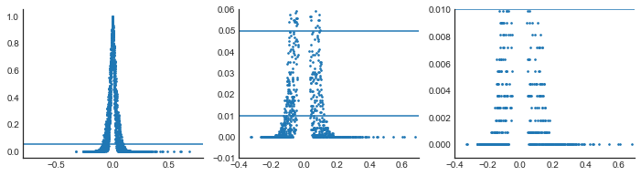

```python
#Let's plot correlation values as a function of pval
fig = plt.figure(figsize=(12, 3))

#plot overall
ax1 = fig.add_subplot(1,3,1)
sns.regplot(fam_corr.values.flatten(), fam_pval.values.flatten(),
            fit_reg=False, scatter_kws={'s':2})
plt.xlim(-0.8, 0.8)
ax1.axhline(y=0.05)

#plot zoom
ax2 = fig.add_subplot(1,3,2)
sns.regplot(fam_corr.values.flatten(), fam_pval.values.flatten(),
            fit_reg=False, scatter_kws={'s':2})
plt.xlim(-0.4, 0.7)
plt.ylim(-.01, 0.06)
ax2.axhline(y=0.05)
ax2.axhline(y=0.01)

#plot zoom
ax2 = fig.add_subplot(1,3,3)
sns.regplot(fam_corr.values.flatten(), fam_pval.values.flatten(),
            fit_reg=False, scatter_kws={'s':2})
plt.xlim(-0.4, 0.7)
plt.ylim(-.001, 0.01)
ax2.axhline(y=0.05)
ax2.axhline(y=0.01)


sns.despine()
```

Right off the bat, we can see that the correlation values don't have to be very large to be deemed significant. Let's think of being greater than 0.2 as pretty significant, given the messiness of the data. Genus data looks almost exactly the same.

```python
def corr_to_edge(corr_df, threshold=False):
    """
    This function takes a table of pairwise comparisons of elements in the index and column
    headers. It then subsets all pairwise comparisons based on the threshold set.

    For each comparison that meets this threhold (postitive or negative), it will create
    an edge in a network. This network will include orphaned elements.
    """
    #stack the correlation df
    edge_df = corr_df.stack().reset_index()
    edge_df.columns = ['element1', 'element2', 'corr_val'] #rename columns
    edge_df = edge_df.loc[edge_df['element1'] != edge_df['element2']] #remove diagonal

    #if a threshold is set, return the table
    if threshold:
        edge_df = edge_df.loc[(edge_df['corr_val'] > threshold) | \
                              (edge_df['corr_val'] < -threshold)]

    return edge_df
```

```python
#get edge files
edge_fam_2 = corr_to_edge(fam_corr, threshold=0.2)
edge_gen_2 = corr_to_edge(gen_corr, threshold=0.2)
```

### Which taxa positively and negatively correlate with the most other taxa?

```python
#Which groups have the most edges?
fam_edge_count = pd.concat([edge_fam_2['element1'], edge_fam_2['element2']])
fam_edge_count = fam_edge_count.value_counts()
print('These families has the greatest number of correlations')
print(fam_edge_count[:10])

gen_edge_count = pd.concat([edge_gen_2['element1'], edge_gen_2['element2']])
gen_edge_count = gen_edge_count.value_counts()
print('These genera has the greatest number of correlations')
print(gen_edge_count[:10])
```

```
These families has the greatest number of correlations
Streptococcaceae       32
Ruminococcaceae        24
Rikenellaceae          24
Erysipelotrichaceae    22
Family_XIII            22
Christensenellaceae    20
Acidaminococcaceae     20
Actinomycetaceae       18
Bacteroidaceae         16
Pasteurellaceae        14
dtype: int64
These genera has the greatest number of correlations
Ruminococcaceae_UCG-002          100
Ruminococcaceae_UCG-005          100
Ruminococcaceae_UCG-003           92
Ruminococcaceae_UCG-010           90
Blautia                           84
Flavonifractor                    78
Ruminococcaceae_NK4A214_group     78
Christensenellaceae_R-7_group     72
Bacteroides                       70
Ruminococcus_1                    68
dtype: int64
```

```python
#Which groups have the most positive edges?
edge_fam_2_pos = edge_fam_2.loc[edge_fam_2['corr_val'] > 0]
fam_pos_edge_count = pd.concat([edge_fam_2_pos['element1'],
                                edge_fam_2_pos['element2']])
fam_pos_edge_count = fam_pos_edge_count.value_counts()
print('These families has the greatest number of positive correlations')
print(fam_pos_edge_count[:10])

edge_gen_2_pos = edge_gen_2.loc[edge_gen_2['corr_val'] > 0]
gen_pos_edge_count = pd.concat([edge_gen_2_pos['element1'],
                                edge_gen_2_pos['element2']])
gen_pos_edge_count = gen_pos_edge_count.value_counts()
print('These genera has the greatest number of positive correlations')
print(gen_pos_edge_count[:10])
```

```
These families has the greatest number of positive correlations
Rikenellaceae          20
Streptococcaceae       16
Actinomycetaceae       14
Ruminococcaceae        14
Family_XIII            14
Erysipelotrichaceae    14
Christensenellaceae    14
Bacteroidaceae         12
Porphyromonadaceae     12
Carnobacteriaceae      10
dtype: int64
These genera has the greatest number of positive correlations
Ruminococcaceae_UCG-005          70
Ruminococcaceae_UCG-002          62
Ruminococcaceae_UCG-003          58
Ruminococcaceae_UCG-010          54
Alistipes                        52
Ruminococcaceae_NK4A214_group    52
Blautia                          52
Ruminococcus_1                   50
Christensenellaceae_R-7_group    46
Ruminococcaceae_UCG-014          46
dtype: int64
```

```python
#Which groups have the most negative edges?
edge_fam_2_neg = edge_fam_2.loc[edge_fam_2['corr_val'] < 0]
fam_neg_edge_count = pd.concat([edge_fam_2_neg['element1'],
                                edge_fam_2_neg['element2']])
fam_neg_edge_count = fam_neg_edge_count.value_counts()
print('These families has the greatest number of negative correlations')
print(fam_neg_edge_count[:10])

edge_gen_2_neg = edge_gen_2.loc[edge_gen_2['corr_val'] < 0]
gen_neg_edge_count = pd.concat([edge_gen_2_neg['element1'],
                                edge_gen_2_neg['element2']])
gen_neg_edge_count = gen_neg_edge_count.value_counts()
print('These genera has the greatest number of negative correlations')
print(gen_neg_edge_count[:10])
```

```
These families has the greatest number of negative correlations
Streptococcaceae       16
Ruminococcaceae        10
Acidaminococcaceae     10
Family_XIII             8
Erysipelotrichaceae     8
Pasteurellaceae         6
Christensenellaceae     6
Veillonellaceae         6
Enterobacteriaceae      6
Rikenellaceae           4
dtype: int64
These genera has the greatest number of negative correlations
Eggerthella                40
Flavonifractor             38
Ruminococcaceae_UCG-002    38
Ruminococcaceae_UCG-010    36
Ruminococcaceae_UCG-003    34
Streptococcus              32
Actinomyces                32
Blautia                    32
Ruminococcaceae_UCG-005    30
Bacteroides                30
dtype: int64
```

### Which taxa positively and negatively correlate with the most other taxa?

From the results above for families, we can see that Streptococcaceae, Ruminococcaceae, and Rikenellaceae seem to have the most interactions with other taxa groups. Other notable families are Christensenellaceae because of previous results from obesity/genetics studies from Ruth Ley's group and Bacteroidaceae simply because the group is so dominant.

For genus, we see a number of Ruminococcaceae genera, a Christensenellaceae genera, and Blautia. Ruminococcaceae seems to split into a bunch of ill-deinfed genera, so we'll have to look at those with some skepticism.

Most correlations in this dataset are positive, so looking at only positive correlations looks largely similar to the overall results. Notable differences are the rise of the family Rikenellaceae.

For negative interactions, the patterns still largely hold, with Streptococcaceae and Ruminococcaceae leading the way. For genus, the group Eggerthella had the most negative interactions. This genus has been implicated in inflammatory bowel disease.

### What cliques/cohorts can we identify?

```python
#Find the largest clique for positive correlations
fam_pos_ntwk = nx.from_pandas_dataframe(edge_fam_2_pos,
                                        'element1', 'element2',
                                        edge_attr=['corr_val'])
gen_pos_ntwk = nx.from_pandas_dataframe(edge_gen_2_pos,
                                        'element1', 'element2',
                                        edge_attr=['corr_val'])

fam_pos_ntwk_cliques = sorted(list(nx.find_cliques(fam_pos_ntwk)),
                              key=len, reverse=True)
gen_pos_ntwk_cliques= sorted(list(nx.find_cliques(gen_pos_ntwk)),
                             key=len, reverse=True)
```

```python
#Look at the 5 largest cliques of families
fam_pos_ntwk_cliques[:5]
```

```
[['Rikenellaceae',
  'Porphyromonadaceae',
  'Bacteroidaceae',
  'Ruminococcaceae',
  'Acidaminococcaceae'],
 ['Actinomycetaceae',
  'Streptococcaceae',
  'Carnobacteriaceae',
  'Micrococcaceae'],
 ['Actinomycetaceae', 'Streptococcaceae', 'Carnobacteriaceae', 'Family_XI'],
 ['Rikenellaceae', 'Porphyromonadaceae', 'Bacteroidaceae', 'Alcaligenaceae'],
 ['Rikenellaceae',
  'Porphyromonadaceae',
  'Desulfovibrionaceae',
  'Acidaminococcaceae']]
```

```python
#Look at the 5 largest cliques of genera
gen_pos_ntwk_cliques[:5]
```

```
[['Ruminococcaceae_UCG-005',
  'Ruminococcaceae_UCG-002',
  'Ruminococcaceae_NK4A214_group',
  'Ruminococcaceae_UCG-010',
  'Christensenellaceae_R-7_group',
  'Ruminiclostridium_6',
  'Ruminococcaceae_UCG-014',
  'Ruminococcaceae_UCG-003',
  'Coprococcus_2',
  'Ruminococcus_1',
  'Lachnospiraceae_UCG-001'],
 ['Ruminococcaceae_UCG-005',
  'Ruminococcaceae_UCG-002',
  'Ruminococcaceae_NK4A214_group',
  'Lachnospiraceae_NK4A136_group',
  'Christensenellaceae_R-7_group',
  'Ruminococcaceae_UCG-003',
  'Ruminiclostridium_6',
  'Ruminococcus_1',
  'Lachnospiraceae_UCG-001',
  'Ruminococcaceae_UCG-014'],
 ['Ruminococcaceae_UCG-005',
  'Ruminococcaceae_UCG-002',
  'Ruminococcaceae_NK4A214_group',
  'Ruminococcaceae_UCG-010',
  'Christensenellaceae_R-7_group',
  'Ruminiclostridium_6',
  'Barnesiella',
  'Ruminococcus_1',
  'Alistipes',
  'Ruminococcaceae_UCG-003'],
 ['Ruminococcaceae_UCG-005',
  'Ruminococcaceae_UCG-002',
  'Ruminococcaceae_NK4A214_group',
  'Ruminococcaceae_UCG-010',
  'Christensenellaceae_R-7_group',
  'Ruminiclostridium_6',
  'Alistipes',
  'Anaerotruncus',
  'Ruminococcus_1',
  'Ruminococcaceae_UCG-003'],
 ['Ruminococcaceae_UCG-005',
  'Ruminococcaceae_UCG-002',
  'Ruminococcaceae_NK4A214_group',
  'Ruminococcaceae_UCG-010',
  'Christensenellaceae_R-7_group',
  'Ruminiclostridium_6',
  'Ruminococcaceae_UCG-014',
  'Family_XIII_AD3011_group',
  'Anaerotruncus',
  'Ruminococcus_1']]
```

### What cliques/cohorts can we identify?

For families, the largest clique of positively correlating taxa was ['Rikenellaceae', 'Porphyromonadaceae', 'Bacteroidaceae', 'Ruminococcaceae', 'Acidaminococcaceae']. These include many of the groups that correlated with the most other species.

For genera, the largest clique was a bunch of Ruminococcaceae and ['Christensenellaceae_R-7_group', 'Coprococcus_2', 'Lachnospiraceae_UCG-001']. A priori, I don't think I was expecting to replicate the Christensenellaceae results from previous papers, but there it is. We'll have to see how these cliques and cohorts line up with the clinical data.

### What isolated taxa/islands seem unresponsive to other taxa?

```python
fam_isolated = set(fam_corr.columns) - \
               set(edge_fam_2[['element1', 'element2']].values.flatten())
gen_isolated = set(gen_corr.columns) - \
               set(edge_gen_2[['element1', 'element2']].values.flatten())
print('Number of isolated families = ' + str(len(fam_isolated)))
print('Number of isolated genera = ' + str(len(gen_isolated)))
```

```
Number of isolated families = 22
Number of isolated genera = 79
```